# Personalized cancer diagnosis

# Additional feature engineering

# 1.0 Data

```python
import pandas as pd
result= pd.read_csv('result.csv')
```

```python
result.head(5)
```

|  | Unnamed: 0 | ID | Gene | Variation | Class | TEXT |
| --- | --- | --- | --- | --- | --- | --- |
| 0 | 0 | 0 | FAM58A | Truncating_Mutations | 1 | cyclin dependent kinases cdks regulate variety... |
| 1 | 1 | 1 | CBL | W802* | 2 | abstract background non small cell lung cancer... |
| 2 | 2 | 2 | CBL | Q249E | 2 | abstract background non small cell lung cancer... |
| 3 | 3 | 3 | CBL | N454D | 3 | recent evidence demonstrated acquired uniparen... |
| 4 | 4 | 4 | CBL | L399V | 4 | oncogenic mutations monomeric casitas b lineag... |

# 2.0 Feature Engineering

## 2.1 Creating a feature that combines Gene & Variation

```python
#combining gene & variation into a single feature
result['Gene+Variation']= result['Gene']+" "+result['Variation']
```

```python
result.head(5)
```

|  | Unnamed: 0 | ID | Gene | Variation | Class | TEXT | Gene+Variation |
| --- | --- | --- | --- | --- | --- | --- | --- |
| 0 | 0 | 0 | FAM58A | Truncating_Mutations | 1 | cyclin dependent kinases cdks regulate variety... | FAM58A Truncating_Mutations |
| 1 | 1 | 1 | CBL | W802* | 2 | abstract background non small cell lung cancer... | CBL W802* |
| 2 | 2 | 2 | CBL | Q249E | 2 | abstract background non small cell lung cancer... | CBL Q249E |
| 3 | 3 | 3 | CBL | N454D | 3 | recent evidence demonstrated acquired uniparen... | CBL N454D |
| 4 | 4 | 4 | CBL | L399V | 4 | oncogenic mutations monomeric casitas b lineag... | CBL L399V |

## 2.2 Creating a feature with word count in each text

```python
# Creating feature 'TEXT_wordcount' which consists of number of words in each text
count=[len(row.split()) for row in result.TEXT.values]
```

```python
print(len(count))
```

```
3321
```

```python
result['TEXT_wordcount']=count
```

```python
result.head(5)
```

|  | Unnamed: 0 | ID | Gene | Variation | Class | TEXT | Gene+Variation | TEXT_wordcount |
| --- | --- | --- | --- | --- | --- | --- | --- | --- |
| 0 | 0 | 0 | FAM58A | Truncating_Mutations | 1 | cyclin dependent kinases cdks regulate variety... | FAM58A Truncating_Mutations | 4370 |
| 1 | 1 | 1 | CBL | W802* | 2 | abstract background non small cell lung cancer... | CBL W802* | 4139 |
| 2 | 2 | 2 | CBL | Q249E | 2 | abstract background non small cell lung cancer... | CBL Q249E | 4139 |
| 3 | 3 | 3 | CBL | N454D | 3 | recent evidence demonstrated acquired uniparen... | CBL N454D | 3841 |
| 4 | 4 | 4 | CBL | L399V | 4 | oncogenic mutations monomeric casitas b lineag... | CBL L399V | 4254 |

# 3.0 Splitting the data

```python
y_true = result['Class'].values
result.Gene      = result.Gene.str.replace('\s+', '_')
result.Variation = result.Variation.str.replace('\s+', '_')

# split the data into test and train by maintaining same distribution of output varaible 'y_true' [stratify=y_true]
X_train, test_df, y_train, y_test = train_test_split(result, y_true, stratify=y_true, test_size=0.2)
# split the train data into train and cross validation by maintaining same distribution of output varaible 'y_train' [stratify=y_train]
train_df, cv_df, y_train, y_cv = train_test_split(X_train, y_train, stratify=y_train, test_size=0.2)

print('Number of data points in train data:', train_df.shape[0])
print('Number of data points in test data:', test_df.shape[0])
print('Number of data points in cross validation data:', cv_df.shape[0])
```

```
Number of data points in train data: 2124
Number of data points in test data: 665
Number of data points in cross validation data: 532
```

# 4.0 Encoding gene, variation & text features

## 4.1 Gene

```python
# one-hot encoding of Gene feature.
gene_vectorizer = TfidfVectorizer()
train_gene_feature_onehotCoding = gene_vectorizer.fit_transform(train_df['Gene'])
test_gene_feature_onehotCoding = gene_vectorizer.transform(test_df['Gene'])
cv_gene_feature_onehotCoding = gene_vectorizer.transform(cv_df['Gene'])
```

```python
print("train_gene_feature_onehotCoding is converted feature using one-hot encoding method. The shape of gene feature:", train_gene_feature_onehotCoding.shape)
```

```
train_gene_feature_onehotCoding is converted feature using one-hot encoding method. The shape of gene feature: (2124, 238)
```

## 4.2 Variation

```python
# one-hot encoding of variation feature.
variation_vectorizer = TfidfVectorizer()
train_variation_feature_onehotCoding = variation_vectorizer.fit_transform(train_df['Variation'])
test_variation_feature_onehotCoding = variation_vectorizer.transform(test_df['Variation'])
cv_variation_feature_onehotCoding = variation_vectorizer.transform(cv_df['Variation'])
```

```python
print("train_variation_feature_onehotEncoded is converted feature using the onne-hot encoding method. The shape of Variation feature:", train_variation_feature_onehotCoding.shape)
```

```
train_variation_feature_onehotEncoded is converted feature using the onne-hot encoding method. The shape of Variation feature: (2124, 1947)
```

## 4.3 Text

```python
# building a CountVectorizer with all the words that occured minimum 10 times in train data
text_vectorizer = TfidfVectorizer(min_df=10, ngram_range=(1,4), max_features=5000)
train_text_feature_onehotCoding = text_vectorizer.fit_transform(train_df['TEXT'])
# getting all the feature names (words)
train_text_features= text_vectorizer.get_feature_names()

# train_text_feature_onehotCoding.sum(axis=0).A1 will sum every row and returns (1*number of features) vector
train_text_fea_counts = train_text_feature_onehotCoding.sum(axis=0).A1

# zip(list(text_features),text_fea_counts) will zip a word with its number of times it occured
text_fea_dict = dict(zip(list(train_text_features),train_text_fea_counts))


print("Total number of unique words in train data :", len(train_text_features))
```

```
Total number of unique words in train data : 5000
```

```python
# don't forget to normalize every feature
train_text_feature_onehotCoding = normalize(train_text_feature_onehotCoding, axis=0)

# we use the same vectorizer that was trained on train data
test_text_feature_onehotCoding = text_vectorizer.transform(test_df['TEXT'])
# don't forget to normalize every feature
test_text_feature_onehotCoding = normalize(test_text_feature_onehotCoding, axis=0)

# we use the same vectorizer that was trained on train data
cv_text_feature_onehotCoding = text_vectorizer.transform(cv_df['TEXT'])
# don't forget to normalize every feature
cv_text_feature_onehotCoding = normalize(cv_text_feature_onehotCoding, axis=0)
```

```python
train_text_feature_onehotCoding.shape
```

```
(2124, 5000)
```

# 5.0 Univariate analysis of the engineered features

## 5.1 Gene+Variation

```python
comb=[len(row.split()) for row in result['Gene+Variation'].values]
```

```python
print(max(comb))
```

```
2
```

- From the above cell, since max len of any row in the 'Gene+Variation' feature is 2, it is a categorical feature

```python
unique = train_df['Gene+Variation'].value_counts()
print('Number of Unique values :', unique.shape[0])
# the top 10 genes that occured most
print(unique.head(10))
```

```
Number of Unique values : 2124
TSC2 S1653P               1
ERBB4 Fusions             1
PTPN11 D61N               1
EGFR A750P                1
BRCA2 V1306I              1
PTEN D92E                 1
PMS2 E5K                  1
MSH6 V509A                1
ROS1 LRIG3-ROS1_Fusion    1
CDKN2A P48L               1
Name: Gene+Variation, dtype: int64
```

```python
print("Ans: There are", unique.shape[0] ,"different categories of genes & variation in the train data, and they are distibuted as follows",)
```

```
Ans: There are 2124 different categories of genes & variation in the train data, and they are distibuted as follows
```

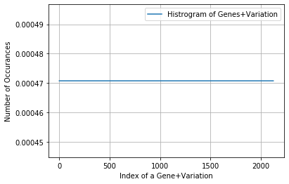

```python
s = sum(unique.values);
h = unique.values/s;
plt.plot(h, label="Histrogram of Genes+Variation")
plt.xlabel('Index of a Gene+Variation')
plt.ylabel('Number of Occurances')
plt.legend()
plt.grid()
plt.show()
```

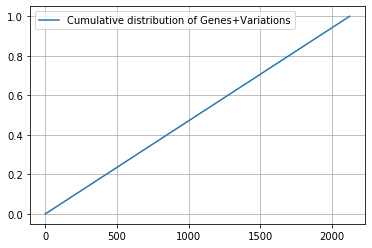

```python
c = np.cumsum(h)
plt.plot(c,label='Cumulative distribution of Genes+Variations')
plt.grid()
plt.legend()
plt.show()
```

- None of the values in this feature have repeated

### 5.1.1 Encoding

```python
gene_var_vectorizer = TfidfVectorizer()
train_gene_var_feature_onehotCoding = gene_var_vectorizer.fit_transform(train_df['Gene+Variation'])
test_gene_var_feature_onehotCoding = gene_var_vectorizer.transform(test_df['Gene+Variation'])
cv_gene_var_feature_onehotCoding = gene_var_vectorizer.transform(cv_df['Gene+Variation'])
```

```python
train_gene_var_feature_onehotCoding= normalize(train_gene_var_feature_onehotCoding, axis=0)
cv_gene_var_feature_onehotCoding= normalize(cv_gene_var_feature_onehotCoding, axis=0)
test_gene_var_feature_onehotCoding= normalize(test_gene_var_feature_onehotCoding, axis=0)
```

```python
train_gene_var_feature_onehotCoding.shape
```

```
(2124, 2166)
```

### 5.1.2 Checking for the feature's influence on the response label

```
For values of alpha =  1e-05 The log loss is: 1.1779979661579758
For values of alpha =  0.0001 The log loss is: 1.1383347022562214
For values of alpha =  0.001 The log loss is: 1.1340800100756958
For values of alpha =  0.01 The log loss is: 1.1700386272918484
For values of alpha =  0.1 The log loss is: 1.2500400994109426
For values of alpha =  1 The log loss is: 1.2583265469377447
```

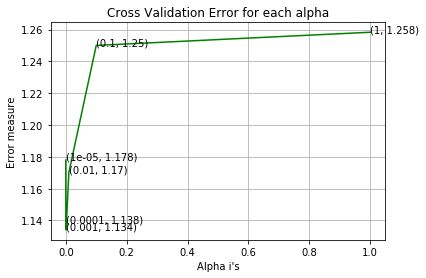

```
For values of best alpha =  0.001 The train log loss is: 0.3781259164690002
For values of best alpha =  0.001 The cross validation log loss is: 1.1340800100756958
For values of best alpha =  0.001 The test log loss is: 1.2223146214779916
```

```python
alpha = [10 ** x for x in range(-5, 1)] # hyperparameter for SGD classifier.

# read more about SGDClassifier() at http://scikit-learn.org/stable/modules/generated/sklearn.linear_model.SGDClassifier.html
# ------------------------------
# default parameters
# SGDClassifier(loss=’hinge’, penalty=’l2’, alpha=0.0001, l1_ratio=0.15, fit_intercept=True, max_iter=None, tol=None,
# shuffle=True, verbose=0, epsilon=0.1, n_jobs=1, random_state=None, learning_rate=’optimal’, eta0=0.0, power_t=0.5,
# class_weight=None, warm_start=False, average=False, n_iter=None)

# some of methods
# fit(X, y[, coef_init, intercept_init, …])	Fit linear model with Stochastic Gradient Descent.
# predict(X)	Predict class labels for samples in X.

#-------------------------------
# video link:
#------------------------------


cv_log_error_array=[]
for i in alpha:
    clf = SGDClassifier(alpha=i, penalty='l2', loss='log', random_state=42)
    clf.fit(train_gene_var_feature_onehotCoding, y_train)
    sig_clf = CalibratedClassifierCV(clf, method="sigmoid")
    sig_clf.fit(train_gene_var_feature_onehotCoding, y_train)
    predict_y = sig_clf.predict_proba(cv_gene_var_feature_onehotCoding)
    cv_log_error_array.append(log_loss(y_cv, predict_y, labels=clf.classes_, eps=1e-15))
    print('For values of alpha = ', i, "The log loss is:",log_loss(y_cv, predict_y, labels=clf.classes_, eps=1e-15))

fig, ax = plt.subplots()
ax.plot(alpha, cv_log_error_array,c='g')
for i, txt in enumerate(np.round(cv_log_error_array,3)):
    ax.annotate((alpha[i],np.round(txt,3)), (alpha[i],cv_log_error_array[i]))
plt.grid()
plt.title("Cross Validation Error for each alpha")
plt.xlabel("Alpha i's")
plt.ylabel("Error measure")
plt.show()


best_alpha = np.argmin(cv_log_error_array)
clf = SGDClassifier(alpha=alpha[best_alpha], penalty='l2', loss='log', random_state=42)
clf.fit(train_gene_var_feature_onehotCoding, y_train)
sig_clf = CalibratedClassifierCV(clf, method="sigmoid")
sig_clf.fit(train_gene_var_feature_onehotCoding, y_train)

predict_y = sig_clf.predict_proba(train_gene_var_feature_onehotCoding)
print('For values of best alpha = ', alpha[best_alpha], "The train log loss is:",log_loss(y_train, predict_y, labels=clf.classes_, eps=1e-15))
predict_y = sig_clf.predict_proba(cv_gene_var_feature_onehotCoding)
print('For values of best alpha = ', alpha[best_alpha], "The cross validation log loss is:",log_loss(y_cv, predict_y, labels=clf.classes_, eps=1e-15))
predict_y = sig_clf.predict_proba(test_gene_var_feature_onehotCoding)
print('For values of best alpha = ', alpha[best_alpha], "The test log loss is:",log_loss(y_test, predict_y, labels=clf.classes_, eps=1e-15))
```

- This feature is useful as the test log loss <2.5(Random model)

# 6.0 Word count

```python
# Normalizing the feature
from sklearn.preprocessing import MinMaxScaler
normalizer = MinMaxScaler()
# normalizer.fit(X_train['price'].values)
#this will rise an error Expected 2D array, got 1D array instead:
normalizer.fit(train_df['TEXT_wordcount'].values.reshape(-1,1))

train_count_norm = normalizer.transform(train_df['TEXT_wordcount'].values.reshape(-1,1))
cv_count_norm = normalizer.transform(cv_df['TEXT_wordcount'].values.reshape(-1,1))
test_count_norm = normalizer.transform(test_df['TEXT_wordcount'].values.reshape(-1,1))
```

```python
print(train_count_norm.shape)
```

```
(2124, 1)
```

## 6.1 Checking for the feature's influence on the response label

```
For values of alpha =  1e-05 The log loss is: 1.8014356480000075
For values of alpha =  0.0001 The log loss is: 1.8014356434635619
For values of alpha =  0.001 The log loss is: 1.8014356451658382
For values of alpha =  0.01 The log loss is: 1.8014356432949388
For values of alpha =  0.1 The log loss is: 1.8014356442173822
For values of alpha =  1 The log loss is: 1.8014356449203064
```

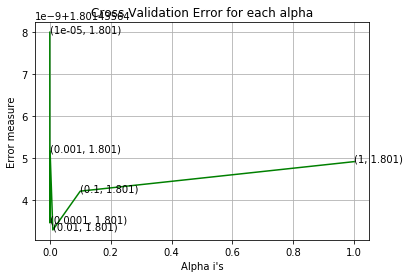

```
For values of best alpha =  0.01 The train log loss is: 1.809621999401289
For values of best alpha =  0.01 The cross validation log loss is: 1.8014356432949388
For values of best alpha =  0.01 The test log loss is: 1.822818160559836
```

```python
alpha = [10 ** x for x in range(-5, 1)] # hyperparameter for SGD classifier.

# read more about SGDClassifier() at http://scikit-learn.org/stable/modules/generated/sklearn.linear_model.SGDClassifier.html
# ------------------------------
# default parameters
# SGDClassifier(loss=’hinge’, penalty=’l2’, alpha=0.0001, l1_ratio=0.15, fit_intercept=True, max_iter=None, tol=None,
# shuffle=True, verbose=0, epsilon=0.1, n_jobs=1, random_state=None, learning_rate=’optimal’, eta0=0.0, power_t=0.5,
# class_weight=None, warm_start=False, average=False, n_iter=None)

# some of methods
# fit(X, y[, coef_init, intercept_init, …])	Fit linear model with Stochastic Gradient Descent.
# predict(X)	Predict class labels for samples in X.

#-------------------------------
# video link:
#------------------------------


cv_log_error_array=[]
for i in alpha:
    clf = SGDClassifier(alpha=i, penalty='l2', loss='log', random_state=42)
    clf.fit(train_count_norm, y_train)
    sig_clf = CalibratedClassifierCV(clf, method="sigmoid")
    sig_clf.fit(train_count_norm, y_train)
    predict_y = sig_clf.predict_proba(cv_count_norm)
    cv_log_error_array.append(log_loss(y_cv, predict_y, labels=clf.classes_, eps=1e-15))
    print('For values of alpha = ', i, "The log loss is:",log_loss(y_cv, predict_y, labels=clf.classes_, eps=1e-15))

fig, ax = plt.subplots()
ax.plot(alpha, cv_log_error_array,c='g')
for i, txt in enumerate(np.round(cv_log_error_array,3)):
    ax.annotate((alpha[i],np.round(txt,3)), (alpha[i],cv_log_error_array[i]))
plt.grid()
plt.title("Cross Validation Error for each alpha")
plt.xlabel("Alpha i's")
plt.ylabel("Error measure")
plt.show()


best_alpha = np.argmin(cv_log_error_array)
clf = SGDClassifier(alpha=alpha[best_alpha], penalty='l2', loss='log', random_state=42)
clf.fit(train_count_norm, y_train)
sig_clf = CalibratedClassifierCV(clf, method="sigmoid")
sig_clf.fit(train_count_norm, y_train)

predict_y = sig_clf.predict_proba(train_count_norm)
print('For values of best alpha = ', alpha[best_alpha], "The train log loss is:",log_loss(y_train, predict_y, labels=clf.classes_, eps=1e-15))
predict_y = sig_clf.predict_proba(cv_count_norm)
print('For values of best alpha = ', alpha[best_alpha], "The cross validation log loss is:",log_loss(y_cv, predict_y, labels=clf.classes_, eps=1e-15))
predict_y = sig_clf.predict_proba(test_count_norm)
print('For values of best alpha = ', alpha[best_alpha], "The test log loss is:",log_loss(y_test, predict_y, labels=clf.classes_, eps=1e-15))
```

- This feature is useful as the test log loss <2.5 (Random model)

# 7.0 Preparing data for the model

```python
# This function plots the confusion matrices given y_i, y_i_hat.
def plot_confusion_matrix(test_y, predict_y):
    C = confusion_matrix(test_y, predict_y)
    # C = 9,9 matrix, each cell (i,j) represents number of points of class i are predicted class j

    A =(((C.T)/(C.sum(axis=1))).T)
    #divid each element of the confusion matrix with the sum of elements in that column

    # C = [[1, 2],
    #     [3, 4]]
    # C.T = [[1, 3],
    #        [2, 4]]
    # C.sum(axis = 1)  axis=0 corresonds to columns and axis=1 corresponds to rows in two diamensional array
    # C.sum(axix =1) = [[3, 7]]
    # ((C.T)/(C.sum(axis=1))) = [[1/3, 3/7]
    #                           [2/3, 4/7]]

    # ((C.T)/(C.sum(axis=1))).T = [[1/3, 2/3]
    #                           [3/7, 4/7]]
    # sum of row elements = 1

    B =(C/C.sum(axis=0))
    #divid each element of the confusion matrix with the sum of elements in that row
    # C = [[1, 2],
    #     [3, 4]]
    # C.sum(axis = 0)  axis=0 corresonds to columns and axis=1 corresponds to rows in two diamensional array
    # C.sum(axix =0) = [[4, 6]]
    # (C/C.sum(axis=0)) = [[1/4, 2/6],
    #                      [3/4, 4/6]]

    labels = [1,2,3,4,5,6,7,8,9]
    # representing A in heatmap format
    print("-"*20, "Confusion matrix", "-"*20)
    plt.figure(figsize=(20,7))
    sns.heatmap(C, annot=True, cmap="YlGnBu", fmt=".3f", xticklabels=labels, yticklabels=labels)
    plt.xlabel('Predicted Class')
    plt.ylabel('Original Class')
    plt.show()

    print("-"*20, "Precision matrix (Columm Sum=1)", "-"*20)
    plt.figure(figsize=(20,7))
    sns.heatmap(B, annot=True, cmap="YlGnBu", fmt=".3f", xticklabels=labels, yticklabels=labels)
    plt.xlabel('Predicted Class')
    plt.ylabel('Original Class')
    plt.show()

    # representing B in heatmap format
    print("-"*20, "Recall matrix (Row sum=1)", "-"*20)
    plt.figure(figsize=(20,7))
    sns.heatmap(A, annot=True, cmap="YlGnBu", fmt=".3f", xticklabels=labels, yticklabels=labels)
    plt.xlabel('Predicted Class')
    plt.ylabel('Original Class')
    plt.show()
```

```python
#Data preparation for ML models.

#Misc. functionns for ML models


def predict_and_plot_confusion_matrix(train_x, train_y,test_x, test_y, clf):
    clf.fit(train_x, train_y)
    sig_clf = CalibratedClassifierCV(clf, method="sigmoid")
    sig_clf.fit(train_x, train_y)
    pred_y = sig_clf.predict(test_x)

    # for calculating log_loss we will provide the array of probabilities belongs to each class
    print("Log loss :",log_loss(test_y, sig_clf.predict_proba(test_x)))
    # calculating the number of data points that are misclassified
    print("Number of mis-classified points :", np.count_nonzero((pred_y- test_y))/test_y.shape[0])
    plot_confusion_matrix(test_y, pred_y)
```

```python
def report_log_loss(train_x, train_y, test_x, test_y,  clf):
    clf.fit(train_x, train_y)
    sig_clf = CalibratedClassifierCV(clf, method="sigmoid")
    sig_clf.fit(train_x, train_y)
    sig_clf_probs = sig_clf.predict_proba(test_x)
    return log_loss(test_y, sig_clf_probs, eps=1e-15)
```

```python
# for the given indices, we will print the name of the features
# and we will check whether the feature present in the test point text or not
def get_impfeature_names(indices, text, gene, var, no_features):
    gene_count_vec = CountVectorizer()
    var_count_vec = CountVectorizer()
    text_count_vec = CountVectorizer(min_df=3)

    gene_vec = gene_count_vec.fit(train_df['Gene'])
    var_vec  = var_count_vec.fit(train_df['Variation'])
    text_vec = text_count_vec.fit(train_df['TEXT'])

    fea1_len = len(gene_vec.get_feature_names())
    fea2_len = len(var_count_vec.get_feature_names())

    word_present = 0
    for i,v in enumerate(indices):
        if (v < fea1_len):
            word = gene_vec.get_feature_names()[v]
            yes_no = True if word == gene else False
            if yes_no:
                word_present += 1
                print(i, "Gene feature [{}] present in test data point [{}]".format(word,yes_no))
        elif (v < fea1_len+fea2_len):
            word = var_vec.get_feature_names()[v-(fea1_len)]
            yes_no = True if word == var else False
            if yes_no:
                word_present += 1
                print(i, "variation feature [{}] present in test data point [{}]".format(word,yes_no))
        else:
            word = text_vec.get_feature_names()[v-(fea1_len+fea2_len)]
            yes_no = True if word in text.split() else False
            if yes_no:
                word_present += 1
                print(i, "Text feature [{}] present in test data point [{}]".format(word,yes_no))

    print("Out of the top ",no_features," features ", word_present, "are present in query point")
```

# 8.0 Stacking the features

```python
# merging gene, variance, text , gene+variation & word_count features

train_gene_var_onehotCoding = hstack((train_gene_feature_onehotCoding,train_variation_feature_onehotCoding))
test_gene_var_onehotCoding = hstack((test_gene_feature_onehotCoding,test_variation_feature_onehotCoding))
cv_gene_var_onehotCoding = hstack((cv_gene_feature_onehotCoding,cv_variation_feature_onehotCoding))

train_x_onehotCoding = hstack((train_gene_var_onehotCoding, train_text_feature_onehotCoding,
                               train_gene_var_feature_onehotCoding, train_count_norm)).tocsr()
train_y = np.array(list(train_df['Class']))

test_x_onehotCoding = hstack((test_gene_var_onehotCoding, test_text_feature_onehotCoding,
                             test_gene_var_feature_onehotCoding, test_count_norm)).tocsr()
test_y = np.array(list(test_df['Class']))

cv_x_onehotCoding = hstack((cv_gene_var_onehotCoding, cv_text_feature_onehotCoding,
                           cv_gene_var_feature_onehotCoding, cv_count_norm)).tocsr()
cv_y = np.array(list(cv_df['Class']))
```

```python
print("One hot encoding features :")
print("(number of data points * number of features) in train data = ", train_x_onehotCoding.shape)
print("(number of data points * number of features) in test data = ", test_x_onehotCoding.shape)
print("(number of data points * number of features) in cross validation data =", cv_x_onehotCoding.shape)
```

```
One hot encoding features :
(number of data points * number of features) in train data =  (2124, 9352)
(number of data points * number of features) in test data =  (665, 9352)
(number of data points * number of features) in cross validation data = (532, 9352)
```

#### I shall be applying logistic regression because of the dimensionality is high & the history of its good performances in previous models

# 9.0 Logistic Regression

## 9.1 With Class balancing

### 9.1.1 Hyper paramter tuning

```
for alpha = 1e-06
Log Loss : 1.133326896586863
for alpha = 1e-05
Log Loss : 1.0831517455996202
for alpha = 0.0001
Log Loss : 0.988238267689689
for alpha = 0.001
Log Loss : 0.995007325981068
for alpha = 0.01
Log Loss : 1.1208714811854623
for alpha = 0.1
Log Loss : 1.5823847613791564
for alpha = 1
Log Loss : 1.7297247513003642
for alpha = 10
Log Loss : 1.7443676570832565
for alpha = 100
Log Loss : 1.7459760481401971
```

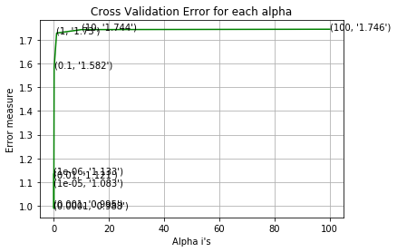

```
For values of best alpha =  0.0001 The train log loss is: 0.38789371818814655
For values of best alpha =  0.0001 The cross validation log loss is: 0.988238267689689
For values of best alpha =  0.0001 The test log loss is: 1.015722205031617
```

```python
# read more about SGDClassifier() at http://scikit-learn.org/stable/modules/generated/sklearn.linear_model.SGDClassifier.html
# ------------------------------
# default parameters
# SGDClassifier(loss=’hinge’, penalty=’l2’, alpha=0.0001, l1_ratio=0.15, fit_intercept=True, max_iter=None, tol=None,
# shuffle=True, verbose=0, epsilon=0.1, n_jobs=1, random_state=None, learning_rate=’optimal’, eta0=0.0, power_t=0.5,
# class_weight=None, warm_start=False, average=False, n_iter=None)

# some of methods
# fit(X, y[, coef_init, intercept_init, …])	Fit linear model with Stochastic Gradient Descent.
# predict(X)	Predict class labels for samples in X.

#-------------------------------
# video link: https://www.appliedaicourse.com/course/applied-ai-course-online/lessons/geometric-intuition-1/
#------------------------------


# find more about CalibratedClassifierCV here at http://scikit-learn.org/stable/modules/generated/sklearn.calibration.CalibratedClassifierCV.html
# ----------------------------
# default paramters
# sklearn.calibration.CalibratedClassifierCV(base_estimator=None, method=’sigmoid’, cv=3)
#
# some of the methods of CalibratedClassifierCV()
# fit(X, y[, sample_weight])	Fit the calibrated model
# get_params([deep])	Get parameters for this estimator.
# predict(X)	Predict the target of new samples.
# predict_proba(X)	Posterior probabilities of classification
#-------------------------------------
# video link:
#-------------------------------------

alpha = [10 ** x for x in range(-6, 3)]
cv_log_error_array = []
for i in alpha:
    print("for alpha =", i)
    clf = SGDClassifier(class_weight='balanced', alpha=i, penalty='l2', loss='log', random_state=42)
    clf.fit(train_x_onehotCoding, train_y)
    sig_clf = CalibratedClassifierCV(clf, method="sigmoid")
    sig_clf.fit(train_x_onehotCoding, train_y)
    sig_clf_probs = sig_clf.predict_proba(cv_x_onehotCoding)
    cv_log_error_array.append(log_loss(cv_y, sig_clf_probs, labels=clf.classes_, eps=1e-15))
    # to avoid rounding error while multiplying probabilites we use log-probability estimates
    print("Log Loss :",log_loss(cv_y, sig_clf_probs))

fig, ax = plt.subplots()
ax.plot(alpha, cv_log_error_array,c='g')
for i, txt in enumerate(np.round(cv_log_error_array,3)):
    ax.annotate((alpha[i],str(txt)), (alpha[i],cv_log_error_array[i]))
plt.grid()
plt.title("Cross Validation Error for each alpha")
plt.xlabel("Alpha i's")
plt.ylabel("Error measure")
plt.show()


best_alpha = np.argmin(cv_log_error_array)
clf = SGDClassifier(class_weight='balanced', alpha=alpha[best_alpha], penalty='l2', loss='log', random_state=42)
clf.fit(train_x_onehotCoding, train_y)
sig_clf = CalibratedClassifierCV(clf, method="sigmoid")
sig_clf.fit(train_x_onehotCoding, train_y)

predict_y = sig_clf.predict_proba(train_x_onehotCoding)
print('For values of best alpha = ', alpha[best_alpha], "The train log loss is:",log_loss(y_train, predict_y, labels=clf.classes_, eps=1e-15))
predict_y = sig_clf.predict_proba(cv_x_onehotCoding)
print('For values of best alpha = ', alpha[best_alpha], "The cross validation log loss is:",log_loss(y_cv, predict_y, labels=clf.classes_, eps=1e-15))
predict_y = sig_clf.predict_proba(test_x_onehotCoding)
print('For values of best alpha = ', alpha[best_alpha], "The test log loss is:",log_loss(y_test, predict_y, labels=clf.classes_, eps=1e-15))
```